# RepData_PeerAssessment1

David Manteigas

Tuesday, April 14, 2015

# Introduction

This assignment was performed using the [Activity Monitoring Data](https://d396qusza40orc.cloudfront.net/repdata%2Fdata%2Factivity.zip). This dataset contains data from a personal activity monitoring device. The variables present in this dataset represent: -**steps**: Number of steps taking in a 5-minute interval (missing values are coded as NA) -**date**: The date on which the measurement was taken in YYYY-MM-DD format -**interval**: Identifier for the 5-minute interval in which measurement was taken

All the calculations were performed using R x64 3.1.1 and/or confirmed by RStudio

## Loading and preprocessing the data

For this part of the assignment, the data was loaded into R and only the variable data was transformed into “Date” format.

```r
Activity_data <- read.csv("C:/Users/David Manteigas/Documents/activity.csv",stringsAsFactors=FALSE)
Activity_data$date <- as.Date(Activity_data$date)
str(Activity_data)
```

```
## 'data.frame':    17568 obs. of  3 variables:
##  $ steps   : int  NA NA NA NA NA NA NA NA NA NA ...
##  $ date    : Date, format: "2012-10-01" "2012-10-01" ...
##  $ interval: int  0 5 10 15 20 25 30 35 40 45 ...
```

## What is mean total number of steps taken per day?

For this part of the assignment, the package dplyr will be used. The following code transforms Activity_data into a tbl and then calculates the total number of steps by day.

```r
library(dplyr)
Activity_data_tbl <- tbl_df(Activity_data[,1:2])
Sum_steps_day <- Activity_data_tbl %>% group_by(date) %>% summarise_each(funs(sum(.,na.rm=TRUE)))
print(Sum_steps_day)
```

```
## Source: local data frame [61 x 2]
##
##          date steps
## 1  2012-10-01     0
## 2  2012-10-02   126
## 3  2012-10-03 11352
## 4  2012-10-04 12116
## 5  2012-10-05 13294
## 6  2012-10-06 15420
## 7  2012-10-07 11015
## 8  2012-10-08     0
## 9  2012-10-09 12811
## 10 2012-10-10  9900
## ..        ...   ...
```

Here an histogram of the total steps by day is produced.

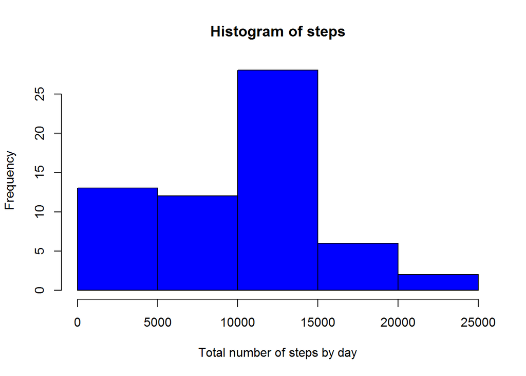

```r
with(Sum_steps_day,{
        hist(steps,col="blue",xlab="Total number of steps by day",ylab="Frequency")
    }
)
```

Mean and Median steps taken by day, using dplyr

```r
Mean_steps_day <- Activity_data_tbl %>% group_by(date) %>% summarise_each(funs(mean(.,na.rm=TRUE)))
Median_steps_day <- Activity_data_tbl %>% group_by(date) %>% summarise_each(funs(median(.,na.rm=TRUE)))
print(Mean_steps_day)
```

```
## Source: local data frame [61 x 2]
##
##          date    steps
## 1  2012-10-01      NaN
## 2  2012-10-02  0.43750
## 3  2012-10-03 39.41667
## 4  2012-10-04 42.06944
## 5  2012-10-05 46.15972
## 6  2012-10-06 53.54167
## 7  2012-10-07 38.24653
## 8  2012-10-08      NaN
## 9  2012-10-09 44.48264
## 10 2012-10-10 34.37500
## ..        ...      ...
```

```r
print(Median_steps_day)
```

```
## Source: local data frame [61 x 2]
##
##          date steps
## 1  2012-10-01    NA
## 2  2012-10-02     0
## 3  2012-10-03     0
## 4  2012-10-04     0
## 5  2012-10-05     0
## 6  2012-10-06     0
## 7  2012-10-07     0
## 8  2012-10-08    NA
## 9  2012-10-09     0
## 10 2012-10-10     0
## ..        ...   ...
```